# hw8

Gian Zlupko

2023-04-21

Load data sets

```r
library(tidyverse)
cars <- read.csv('cars.csv')
crime <- read.csv('crime.csv')
bachelor <- read.csv('bachelor.csv')
food <- read.csv('food_data.csv')
```

## Exercise 1

#### *Do a correspondence analysis for the car-ratings (file cars.txt). Explain how this table can be considered as a contingency table.The data are averaged ratings for 24 car types from a sample of 40 persons. The marks range from 1 (very good) to 6 (very bad).*

```r
library(FactoMineR)
library(ca)
library(factoextra)

# subset and clean the data
cars_sub = cars %>%
  rename(model = row.names) %>%
  mutate(model = as.factor(model),
         Type = as.factor(Type)) %>%
  select(-X)
head(cars_sub)
```

```
##     model    Type Model Economy Service Long.run.Value Price Design SportyCar
## 1    Audi     100   3.9     2.8     2.2            4.2   3.0    3.1       2.4
## 2     BMW 5series   4.8     1.6     1.9            5.0   2.0    2.5       1.6
## 3 Citroen      AX   3.0     3.8     3.8            2.7   4.0    4.4       4.0
## 4 Ferrari     N/A    NA     5.3     2.9            2.2   5.9    1.7       1.1
## 5    Fiat     Uno   2.1     3.9     4.0            2.6   4.5    4.4       4.4
## 6    Ford  Fiesta   2.3     3.1     3.4            2.6   3.2    3.3       3.6
##   Safety EasyHandling
## 1    2.8           NA
## 2    2.8           NA
## 3    2.6           NA
## 4    3.3          4.3
## 5    2.2           NA
## 6    2.8           NA
```

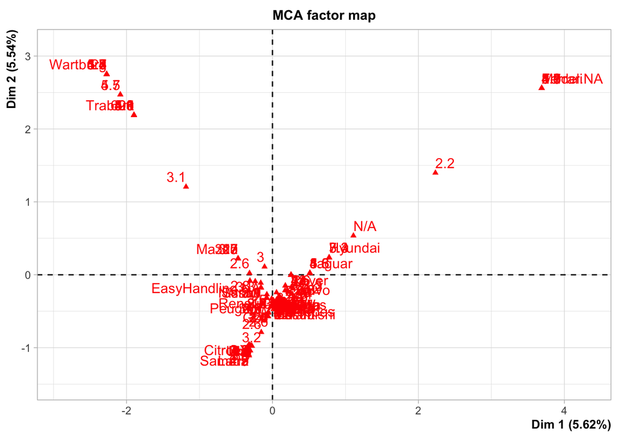

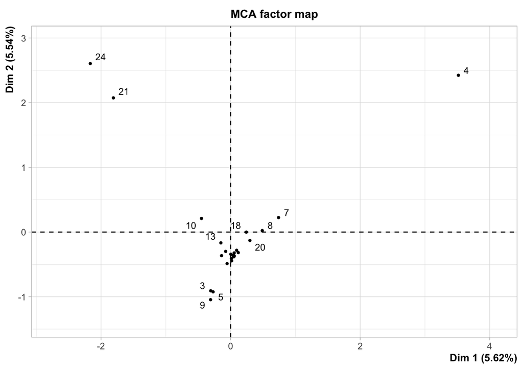

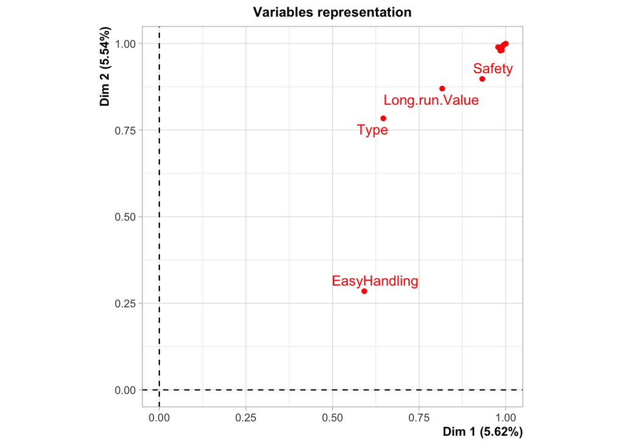

```r
# fit MCA
mca_cars <- MCA(cars)
```

This table can be considered a contingency table because the data that are shown for the rating variables can be considered frequencies. The data are average responses to a set of ratings that range from 1 to 6. The scores are thus the average of the individual ratings that were collected by researchers for each of the 24 cars.

## Exercise 2

#### *Write an R function to compute the chi-square statistic of independence. Test the null using for the bachelor data (file bachelors.txt). The data consists of observations of 202,100 bachelors from France and give the frequencies for different sets of modalities classified into regions. The variables (modalities) are: A=Philosophy-Letters, B=Economics and Social Sciences, C=Mathematics and Physics, D=Mathematics and Natural Sciences, E=Mathematics and Techniques, F=Industrial Techniques, G=Economic Techniques, H Computer Techniques.*

First, I write a custom function to compute the chi-square statistic of independence:

```r
custom_chi <- function(x) {

  row_sums = rowSums(x)
  col_sums = colSums(x)
  total_sum = sum(x)
  expect_freq = outer(row_sums, col_sums)/ total_sum
  # calculate chi-square
  chi_square = sum((x - expect_freq)^2 / expect_freq)
  # returns the chi-square test statistic
  # degrees of freedom and p-value
  df = (nrow(x) - 1)*(ncol(x)-1)
  p_value = 1- pchisq(chi_square, df)
  test_result = list(chi_square = chi_square, df = df, p_value = p_value)
  return(test_result)
  }
```

Next, I use the custom chi-square function on the bachelor data

```r
# create a subset to apply the function to
bachelor_sub <- bachelor %>%
  select(A:H)

# print out the test of independence results using the custom function
custom_chi(bachelor_sub)
```

```
## $chi_square
## [1] 4354.548
##
## $df
## [1] 147
##
## $p_value
## [1] 0
```

The test indicates that the variables are not independent.

## Exercise 3

*Do correspondence analysis of the U.S. crime data (file UScrime.txt), and determine the absolute contributions for the first three axes. How can you interpret the third axis? Try to identify the states with one of the four regions to which it belongs. Do you think the four regions have a different behavior with respect to crime? This is a data set consisting of 50 measurements of 7 variables. It contains the number of crimes in the 50 states of the U.S. classified according to 7 categories. Region is 1 for Northeast, 2 for Midwest, 3 for South and 4 for West. Division is 1 for New England, 2 for Mid Atlantic, 3 for E N central, 4 for W N Central, 5 for S Atlantic, 6 for E S Central, 7 for W S Central, 8 for Mountain and 9 for Pacific.*

First, I subset the crime data and fit CA

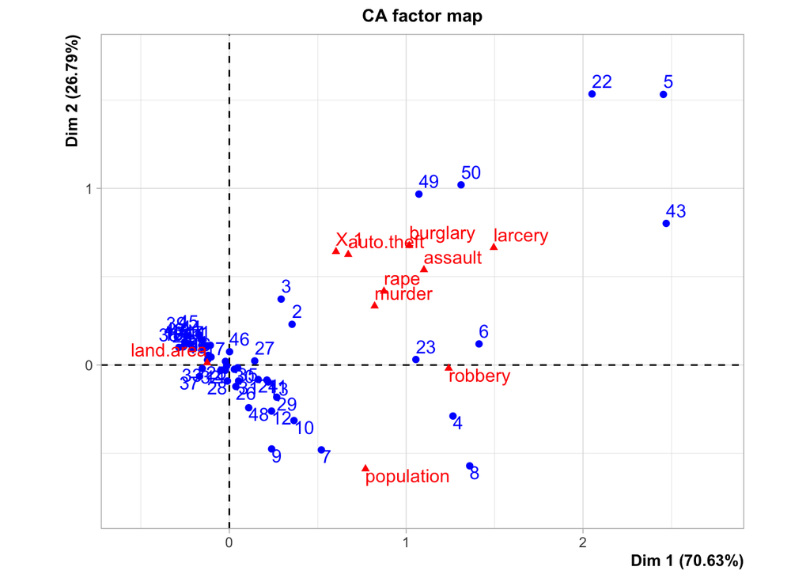

```r
# sub set to return only frequency data
crime_sub <- crime %>%
  select(-c(X.2, state, X, region, division))

# correspondence analysis
crime_ca <- CA(crime_sub)
```

Next, I inspect how the variables load onto the dimensions

```r
crime_contribution <- as.data.frame(crime_ca$col$contrib)
head(crime_contribution)
```

```
##                 Dim 1        Dim 2      Dim 3        Dim 4       Dim 5
## land.area  11.7010611  0.315241799 0.10774336  0.002000968  0.01752490
## population 35.9754865 55.327365403 0.31115467  0.097567314  1.15281166
## murder      0.0592085  0.025817988 0.08862094  0.254201552  0.01576177
## rape        0.1527643  0.092071405 0.68330780  0.159300687  0.41369193
## robbery     1.9205214  0.001097969 0.08371136 46.156732853 50.78422886
## assault    14.1470042  8.947227194 0.48499727 44.499130215 30.36782520
```

First, I re-attach the states to the loadings data for dimension 3 so that I can determine which states have the greatest loading onto dimension 3.

```r
states_dim <- as.data.frame(crime_ca$row)
dim3 <- states_dim[, 3]
states <- crime[, 2]
dim3_states <- data.frame(cbind(states, dim3))

# sort by frequency
sorted <- dim3_states[order(dim3_states$dim3, decreasing= TRUE),]
head(sorted)
```

```
##    states                 dim3
## 18     ND 7.56746203378152e-05
## 5      RI    0.651779054293352
## 4      MA    0.285061229045851
## 49     AK   0.0595216366300291
## 9      PA   0.0455388656131938
## 30     KY   0.0257181927171965
```

The results show that the states, Rhode Island and Massachusetts, load most strongly onto dimension 3. So in terms of which region dimension 3 belongs, the results indicate that it is the east coast (New England in particular).

Finally, the question asks, *Do you think the four regions have a different behavior with respect to crime?*

To answer this question, I visualize a biplot of the CA results on the first two dimensions.

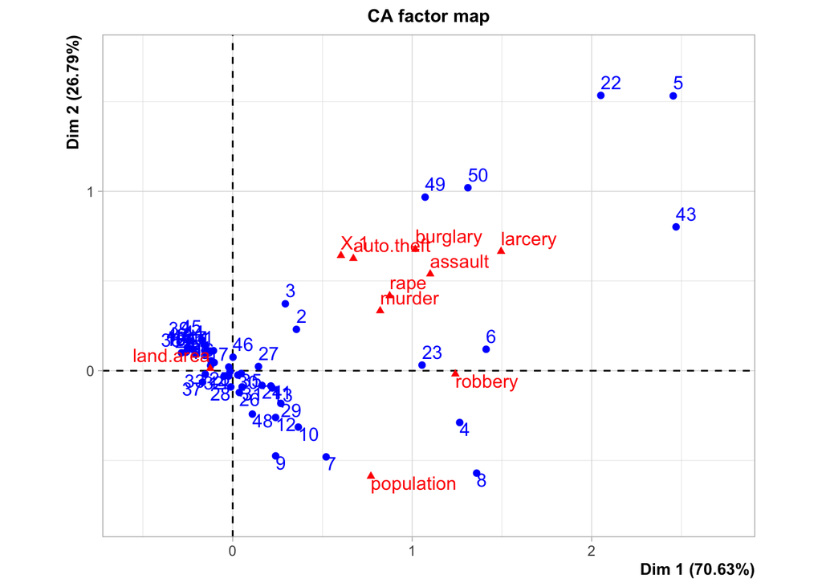

```r
plot(crime_ca)
```

Based on visual inspection of the biplot, I do think that the states have a different behavior with respect to crime. For example, we can see that some states in the upper right quadrant of the 2-D space have relatively high values of Dimension 1 and Dimension 2 crimes. Moreover, some of these states have low population, such as the ones I pointed out in the upper righthand quadrant whereas other states have higher population.

## Exercise 4

*Consider the food data (file food.txt). Given that all of the variables are measured in the same units (dollars), explain how this table can be considered as a contingency table. Perform a correspondence analysis and compare the results to those obtained with the PCA analysis of the correlation matrix. The data set consists of the average expenditures on food for several different types of families (manual workers = MA, employees = EM, managers = CA) with different numbers of children (2,3,4 or 5 children).*

First I inspect the data set:

```r
head(food)
```

```
##   X ID Workertype bread vegetables fruits meat poultry milk wine
## 1 1  1        MA2   332        428    354 1437     526  247  427
## 2 2  2        EM2   293        559    388 1527     567  239  258
## 3 3  3        CA2   372        767    562 1948     927  235  433
## 4 4  4        MA3   406        563    341 1507     544  324  407
## 5 5  5        EM3   386        608    396 1501     558  319  363
## 6 6  6        CA3   438        843    689 2345    1148  243  341
```

The data in the food data set can be considered a contingency table since the counts that we observe in the table can be easily transformed into frequency data with marginal probabilities.

Below, I perform CA. First, I remove the variable ‘Workertype’ and the rowID variables.

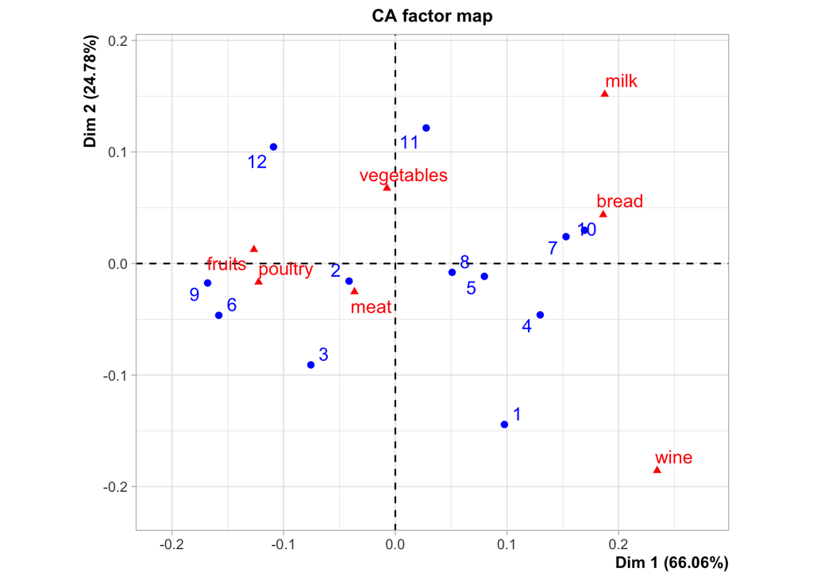

```r
food_sub = food %>%
  select(-c(X, ID, Workertype))

food_ca <- CA(food_sub)
```

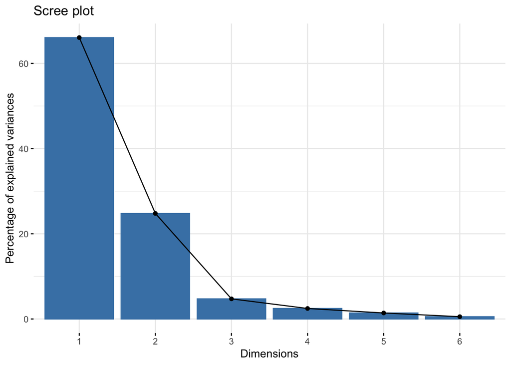

```r
fviz_screeplot(food_ca)
```

The scree plot indicates that 2 dimensions sufficiently captures enough variance in the original data.

We can return the specific eigenvalues below.

```r
food_ca$eig
```

```
##         eigenvalue percentage of variance cumulative percentage of variance
## dim 1 0.0139275913             66.0607153                          66.06072
## dim 2 0.0052247270             24.7816865                          90.84240
## dim 3 0.0009972617              4.7301662                          95.57257
## dim 4 0.0005210095              2.4712284                          98.04380
## dim 5 0.0002978663              1.4128260                          99.45662
## dim 6 0.0001145604              0.5433776                         100.00000
```

*Perform a correspondence analysis and compare the results to those obtained with the PCA analysis of the correlation matrix.*

Next, I generate a correlation matrix and use the matrix as input for PCA.

```r
food_corr_mat = cor(food_sub)
food_corr_mat
```

```
##                bread vegetables     fruits       meat    poultry        milk
## bread      1.0000000  0.5931102  0.1961388  0.3212691  0.2480083 0.855574797
## vegetables 0.5931102  1.0000000  0.8562502  0.8810807  0.8267774 0.662798738
## fruits     0.1961388  0.8562502  1.0000000  0.9594767  0.9255419 0.332188558
## meat       0.3212691  0.8810807  0.9594767  1.0000000  0.9817853 0.374590641
## poultry    0.2480083  0.8267774  0.9255419  0.9817853  1.0000000 0.232891845
## milk       0.8555748  0.6627987  0.3321886  0.3745906  0.2328918 1.000000000
## wine       0.3037612 -0.3564682 -0.4862806 -0.4372353 -0.4001570 0.006879604
##                    wine
## bread       0.303761226
## vegetables -0.356468250
## fruits     -0.486280578
## meat       -0.437235281
## poultry    -0.400157002
## milk        0.006879604
## wine        1.000000000
```

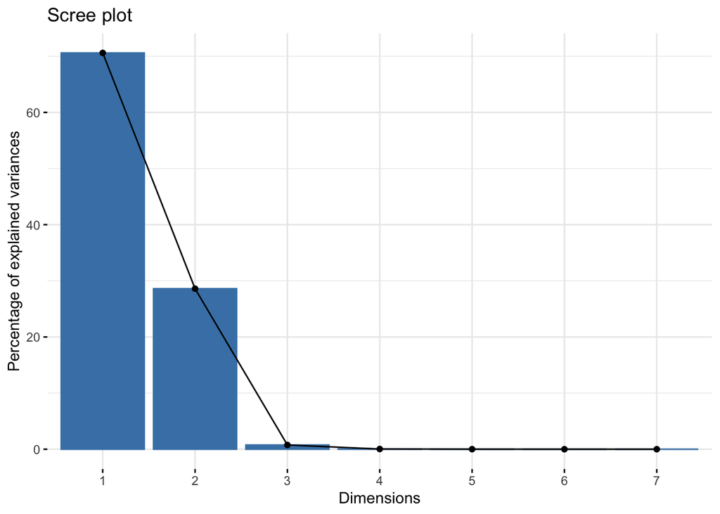

```r
# PCA on the corr mat
food_pca <- princomp(food_corr_mat, cor = TRUE)

fviz_screeplot(food_pca)
```

The same results for an analysis of how many dimensions to retain is identified here, too, using PCA, as was demonstrated above using CA.